# EDA

## Exploratory Data Analysis

```python
# Import the necessary libraries
import datetime
# ignore user warnings
import warnings

import matplotlib.pyplot as plt
# import numpy as np
# import pandas as pd
import seaborn as sns
# from scipy import stats
from scipy.stats import normaltest

from utils import load_data

warnings.filterwarnings("ignore")

sns.set_style("darkgrid")
sns.set_palette("Set2")
sns.set_context("notebook", font_scale=1.5, rc={"lines.linewidth": 2.5})
```

### Data Sources

This dataset comprises information from 100 machines throughout the year 2015, providing an extensive hourly time series. The dataset comprises of five data sources.

1. Telemetry Data (PdM_telemetry.csv): For the year 2015, the dataset provides hourly average measurements of voltage, rotation, pressure, and vibration collected from 100 machines.
2. Error (PdM_errors.csv): These errors occur while the machines are in operation but do not result in machine shutdown, and thus, they are not categorized as failures. The error date and times are rounded to the nearest hour to align with the telemetry data collection frequency
3. Maintenance (PdM_maint.csv): If a machine component is replaced, it is recorded in this table. Component replacements occur in two situations: 1) During regular scheduled visits, technicians perform proactive maintenance by replacing the component. 2) In case of a component breakdown, technicians conduct unscheduled maintenance to replace the faulty component, which is considered a failure and captured in the Failures data. The maintenance data includes records from both 2014 and 2015 and is rounded to the nearest hour to align with the hourly telemetry data collection rate.
4. Failures (PdM_failures.csv): Each entry in this dataset signifies the replacement of a failed component.
5. Machines (PdM_Machines.csv): Contains the model type and age of the Machines.

### Load Data

```python
# Load data
df_telemetry, df_errors, df_maintenance, df_failures, df_machines = load_data()
```

### Telemetry Data

```python
df_telemetry.shape
```

```
(876100, 6)
```

```python
df_telemetry.head()
```

|  | datetime | machineID | volt | rotate | pressure | vibration |
| --- | --- | --- | --- | --- | --- | --- |
| 0 | 2015-01-01 06:00:00 | 1 | 176.217853 | 418.504078 | 113.077935 | 45.087686 |
| 1 | 2015-01-01 07:00:00 | 1 | 162.879223 | 402.747490 | 95.460525 | 43.413973 |
| 2 | 2015-01-01 08:00:00 | 1 | 170.989902 | 527.349825 | 75.237905 | 34.178847 |
| 3 | 2015-01-01 09:00:00 | 1 | 162.462833 | 346.149335 | 109.248561 | 41.122144 |
| 4 | 2015-01-01 10:00:00 | 1 | 157.610021 | 435.376873 | 111.886648 | 25.990511 |

```python
df_telemetry.describe()
```

|  | datetime | machineID | volt | rotate | pressure | vibration |
| --- | --- | --- | --- | --- | --- | --- |
| count | 876100 | 876100.000000 | 876100.000000 | 876100.000000 | 876100.000000 | 876100.000000 |
| mean | 2015-07-02 18:00:00 | 50.500000 | 170.777736 | 446.605119 | 100.858668 | 40.385007 |
| min | 2015-01-01 06:00:00 | 1.000000 | 97.333604 | 138.432075 | 51.237106 | 14.877054 |
| 25% | 2015-04-02 12:00:00 | 25.750000 | 160.304927 | 412.305714 | 93.498181 | 36.777299 |
| 50% | 2015-07-02 18:00:00 | 50.500000 | 170.607338 | 447.558150 | 100.425559 | 40.237247 |
| 75% | 2015-10-02 00:00:00 | 75.250000 | 181.004493 | 482.176600 | 107.555231 | 43.784938 |
| max | 2016-01-01 06:00:00 | 100.000000 | 255.124717 | 695.020984 | 185.951998 | 76.791072 |
| std | NaN | 28.866087 | 15.509114 | 52.673886 | 11.048679 | 5.370361 |

```python
# Number of unique machines in the telemetry data
df_telemetry.machineID.nunique()
```

```
100
```

```python
# Is there any missing data?
df_telemetry.isnull().values.any()
```

```
False
```

```python
# what is the time range for the data?
print(
    f"Telemetry data ranges from: {min(df_telemetry.datetime)} to {max(df_telemetry.datetime)}"
)
```

```
Telemetry data ranges from: 2015-01-01 06:00:00 to 2016-01-01 06:00:00
```

```python
# check if there are any duplicate rows
df_telemetry.duplicated(["datetime", "machineID"]).any()
```

```
False
```

No duplicates, no missing values, hmm ...

```python
def plot_machine_telemetry(machineID, start_date, end_date):
    """ Plot the telemetry data for a given machine and time period.

    Parameters
    ----------
    machineID : int
        ID of the machine to plot the telemetry data for.
    start_date : str
        Start date of the time period to plot the telemetry data for.
    end_date : str
        End date of the time period to plot the telemetry data for.

    Returns
    -------
    None
    """
    # filter the data for the given machine and time period
    start_datetime = datetime.datetime.strptime(start_date, "%Y-%m-%d")
    end_datetime = datetime.datetime.strptime(end_date, "%Y-%m-%d")
    plot_df = df_telemetry.loc[
        (df_telemetry["machineID"] == machineID)
        & (df_telemetry["datetime"] >= start_datetime)
        & (df_telemetry["datetime"] <= end_datetime)
    ]

    # create a plot for each of the telemetry variables
    fig, axes = plt.subplots(nrows=2, ncols=2, figsize=(20, 20))
    fig.subplots_adjust(hspace=0.3)
    plot_df.plot(x="datetime", y="volt", title="voltage", ax=axes[0, 0])
    plot_df.plot(x="datetime", y="rotate", title="rotate", ax=axes[0, 1])
    plot_df.plot(x="datetime", y="pressure", title="pressure", ax=axes[1, 0])
    plot_df.plot(x="datetime", y="vibration", title="vibration", ax=axes[1, 1])
    plt.show()
```

Plotting a shorter time period. Otherwise, difficult to see the pattern.

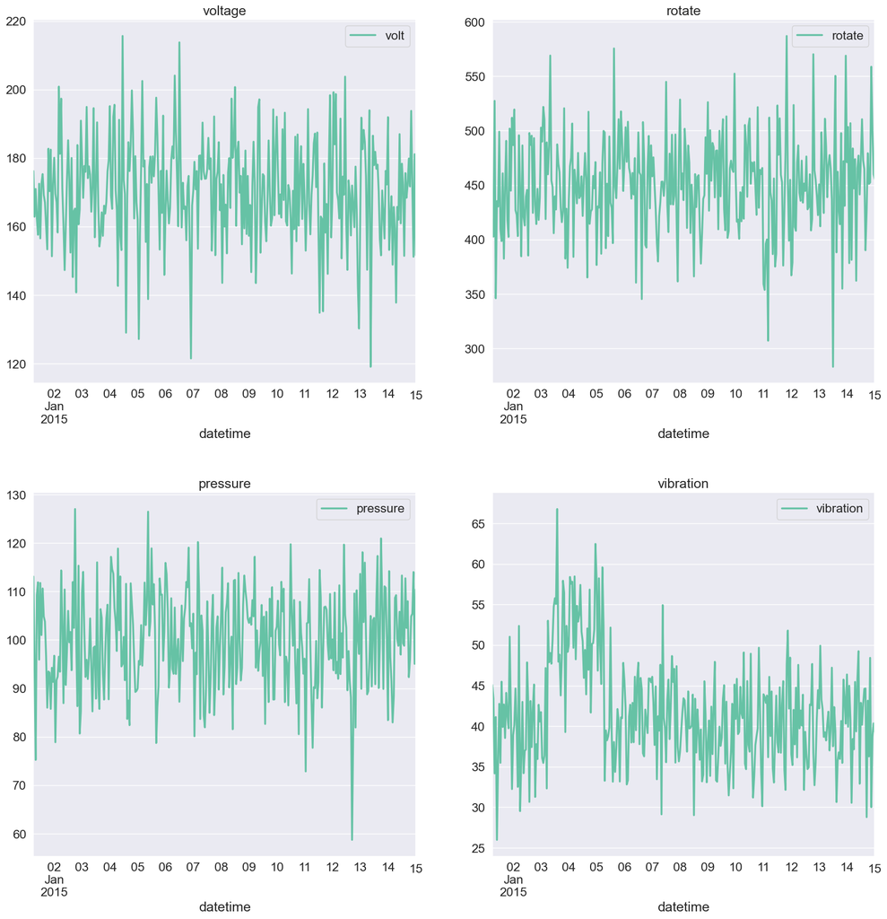

```python
plot_machine_telemetry(1, "2015-01-01", "2015-01-15")
```

Plot the timeseries plots of two machines together, to see if there are differences!

```python
def plot_machine_telemetry(machineID1, machineID2, start_date, end_date):
    # filter the data for the given machines and time period
    start_datetime = datetime.datetime.strptime(start_date, "%Y-%m-%d")
    end_datetime = datetime.datetime.strptime(end_date, "%Y-%m-%d")
    plot_df1 = df_telemetry.loc[
        (df_telemetry["machineID"] == machineID1)
        & (df_telemetry["datetime"] >= start_datetime)
        & (df_telemetry["datetime"] <= end_datetime)
    ]
    plot_df2 = df_telemetry.loc[
        (df_telemetry["machineID"] == machineID2)
        & (df_telemetry["datetime"] >= start_datetime)
        & (df_telemetry["datetime"] <= end_datetime)
    ]

    fig, axes = plt.subplots(nrows=2, ncols=2, figsize=(20, 14))
    fig.subplots_adjust(hspace=0.3)
    plot_df1.plot(
        x="datetime",
        y="volt",
        title="voltage",
        ax=axes[0, 0],
        label="Machine {}".format(machineID1),
    )
    plot_df2.plot(
        x="datetime",
        y="volt",
        title="voltage",
        ax=axes[0, 0],
        label="Machine {}".format(machineID2),
    )
    plot_df1.plot(
        x="datetime",
        y="rotate",
        title="rotate",
        ax=axes[0, 1],
        label="Machine {}".format(machineID1),
    )
    plot_df2.plot(
        x="datetime",
        y="rotate",
        title="rotate",
        ax=axes[0, 1],
        label="Machine {}".format(machineID2),
    )
    plot_df1.plot(
        x="datetime",
        y="pressure",
        title="pressure",
        ax=axes[1, 0],
        label="Machine {}".format(machineID1),
    )
    plot_df2.plot(
        x="datetime",
        y="pressure",
        title="pressure",
        ax=axes[1, 0],
        label="Machine {}".format(machineID2),
    )
    plot_df1.plot(
        x="datetime",
        y="vibration",
        title="vibration",
        ax=axes[1, 1],
        label="Machine {}".format(machineID1),
    )
    plot_df2.plot(
        x="datetime",
        y="vibration",
        title="vibration",
        ax=axes[1, 1],
        label="Machine {}".format(machineID2),
    )
    for ax in axes.flatten():
        ax.legend()
    plt.show()
```

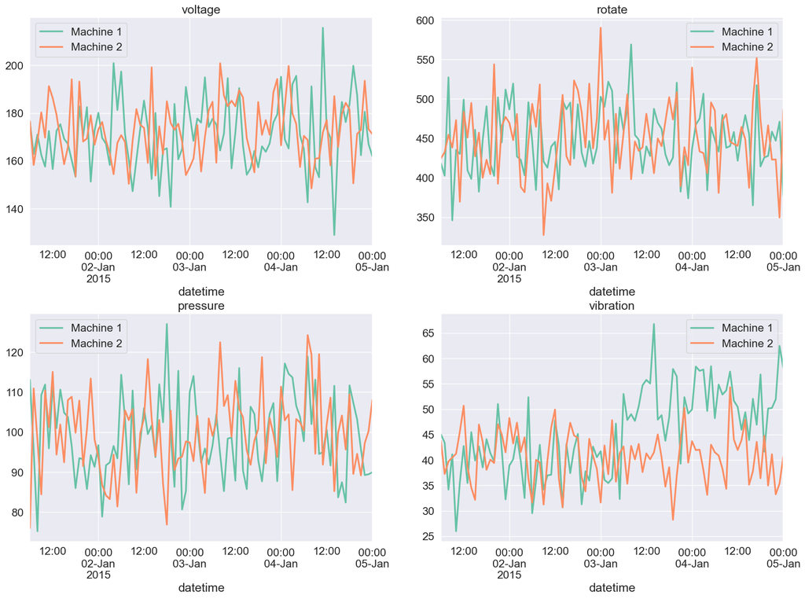

```python
plot_machine_telemetry(1, 2, "2015-01-01", "2015-01-05")
```

### Data Distribution

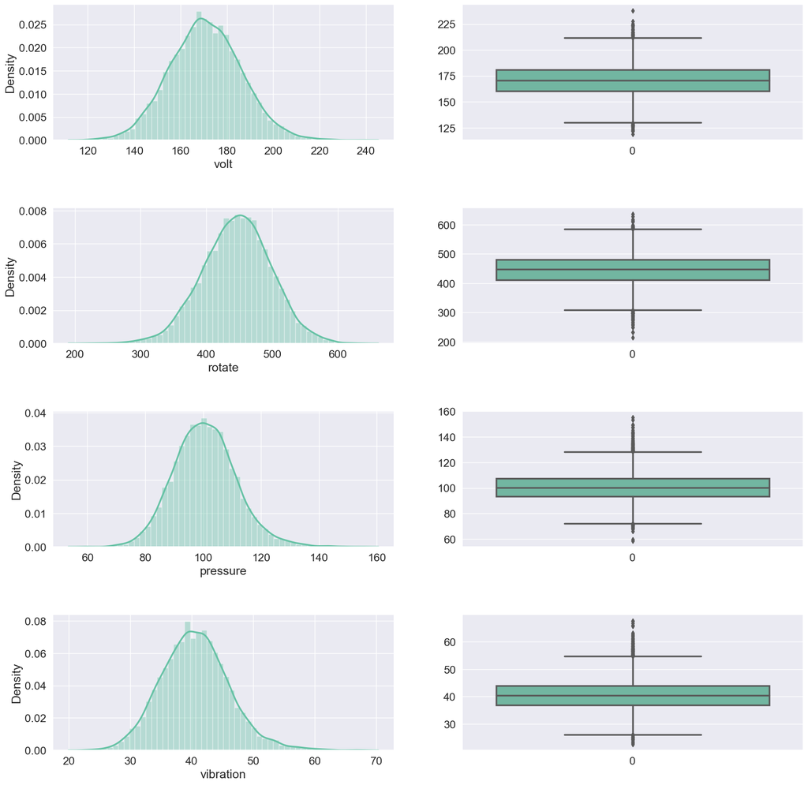

```python
# A function to plot the histogram and box plot for all telemetry values for a given machine
def plot_machine_telemetry_hist(machineID):
    """ Plot the histogram and box plot for all telemetry values for a given machine.

    Parameters
    ----------
    machineID : int
        ID of the machine to plot the telemetry data for.

    Returns
    -------
    None
    """
    # filter the data for the given machine
    plot_df = df_telemetry.loc[df_telemetry["machineID"] == machineID]

    fig, axes = plt.subplots(nrows=4, ncols=2, figsize=(20, 20))
    fig.subplots_adjust(hspace=0.5)
    sns.distplot(plot_df["volt"], ax=axes[0, 0])
    sns.boxplot(plot_df["volt"], ax=axes[0, 1])
    sns.distplot(plot_df["rotate"], ax=axes[1, 0])
    sns.boxplot(plot_df["rotate"], ax=axes[1, 1])
    sns.distplot(plot_df["pressure"], ax=axes[2, 0])
    sns.boxplot(plot_df["pressure"], ax=axes[2, 1])
    sns.distplot(plot_df["vibration"], ax=axes[3, 0])
    sns.boxplot(plot_df["vibration"], ax=axes[3, 1])
    plt.show()


plot_machine_telemetry_hist(machineID=1)
```

### Are the telemetry variables normally distributed?

We apply D'Agostino and Pearson's omnibus normality test. Its based on kurtois and skewness.

```python
def normality_test(machineID):
    # filter the data for the given machine
    plot_df = df_telemetry.loc[df_telemetry["machineID"] == machineID]

    # test for normality
    for col in ["volt", "rotate", "pressure", "vibration"]:
        print(f"Normality test for {col} for machine {machineID}")
        print(normaltest(plot_df[col]))
        print("\n")


normality_test(1)
```

```
Normality test for volt for machine 1
NormaltestResult(statistic=12.119853216962973, pvalue=0.0023345722190421534)


Normality test for rotate for machine 1
NormaltestResult(statistic=35.79596132281163, pvalue=1.6865754000864527e-08)


Normality test for pressure for machine 1
NormaltestResult(statistic=238.38331828215757, pvalue=1.720759382097052e-52)


Normality test for vibration for machine 1
NormaltestResult(statistic=256.5133753274386, pvalue=1.9898863846130465e-56)
```

Since all of the p-values are less than the significance level of 0.05, we can conclude that all of them do not follow a normal distribution. The results provide strong evidence against the assumption of normality

#### Observation

- It looks like it is a synthetic dataset, so there are no missing values. But we can see that the data is not entirely clean. There are a few spikes in the data that are likely due to sensor malfunction.
- There are 100 machines in this dataset.
- There are no duplicate rows in the dataset.
- Volt, rotate, pressure, and vibration all do not have a normal distribution, but there are some outliers in the data.

### Error logs Data

These are errors which are logged while the machine is still running.

```python
df_errors["errorID"] = df_errors["errorID"].astype("category")
print(f"No. of errors: {df_errors.shape[0]}")
df_errors.head()
```

```
No. of errors: 3919
```

|  | datetime | machineID | errorID |
| --- | --- | --- | --- |
| 0 | 2015-01-03 07:00:00 | 1 | error1 |
| 1 | 2015-01-03 20:00:00 | 1 | error3 |
| 2 | 2015-01-04 06:00:00 | 1 | error5 |
| 3 | 2015-01-10 15:00:00 | 1 | error4 |
| 4 | 2015-01-22 10:00:00 | 1 | error4 |

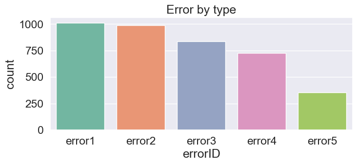

```python
# plot the errors by type to see the distribution
fig, ax = plt.subplots(figsize=(8, 3))
ax = sns.countplot(x="errorID", data=df_errors)
ax.set_title("Error by type")
plt.show()
```

- error1 and error2 are the most common errors
- error5 is the least common

### Maintenance Data

The dataset includes records of component replacements, which are captured in the maintenance table. Components are replaced in two scenarios:

**Proactive Maintenance:** During the regular scheduled visits, technicians proactively replace components as part of preventive maintenance measures. These replacements are logged in the dataset, indicating planned maintenance actions.

**Reactive Maintenance:** In cases where a component experiences a breakdown, technicians perform unscheduled maintenance to replace the faulty component. These instances are considered failures, and the corresponding data is recorded under the failures table.

The maintenance data contains records both from 2014 and 2015.

```python
df_maintenance["comp"] = df_maintenance["comp"].astype("category")
print(f"No. of maintenance records: {df_maintenance.shape[0]}")
df_maintenance.head()
```

```
No. of maintenance records: 3286
```

|  | datetime | machineID | comp |
| --- | --- | --- | --- |
| 0 | 2014-06-01 06:00:00 | 1 | comp2 |
| 1 | 2014-07-16 06:00:00 | 1 | comp4 |
| 2 | 2014-07-31 06:00:00 | 1 | comp3 |
| 3 | 2014-12-13 06:00:00 | 1 | comp1 |
| 4 | 2015-01-05 06:00:00 | 1 | comp4 |

```python
# unique years in the data
df_maintenance["datetime"].dt.year.unique()
```

```
array([2014, 2015, 2016], dtype=int32)
```

2016 is only one record

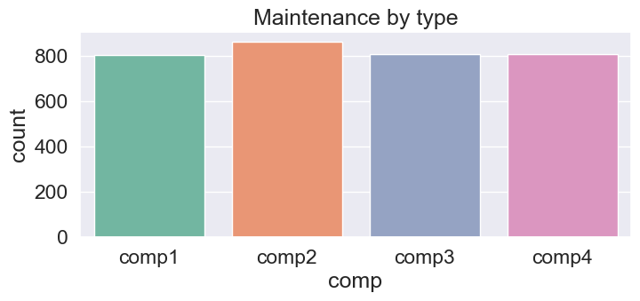

```python
# plot the maintenance by type to see the distribution
fig, ax = plt.subplots(figsize=(8, 3))
ax = sns.countplot(x="comp", data=df_maintenance)
ax.set_title("Maintenance by type")
plt.show()
```

- All components have similar number of records except for component 2 which has a slightly higher number of records.
- This could suggest that maybe during the scheduled maintenance, each component is replaced.

#### **Machines**

This data set includes some information about the machines: model type and age (years in service).

```python
df_machines["model"] = df_machines["model"].astype("category")
print(f"No. of machines: {df_machines.shape[0]}")
df_machines.head()
```

```
No. of machines: 100
```

|  | machineID | model | age |
| --- | --- | --- | --- |
| 0 | 1 | model3 | 18 |
| 1 | 2 | model4 | 7 |
| 2 | 3 | model3 | 8 |
| 3 | 4 | model3 | 7 |
| 4 | 5 | model3 | 2 |

```python
df_machines.describe()
```

|  | machineID | age |
| --- | --- | --- |
| count | 100.000000 | 100.000000 |
| mean | 50.500000 | 11.330000 |
| std | 29.011492 | 5.856974 |
| min | 1.000000 | 0.000000 |
| 25% | 25.750000 | 6.750000 |
| 50% | 50.500000 | 12.000000 |
| 75% | 75.250000 | 16.000000 |
| max | 100.000000 | 20.000000 |

```python
# unique models in the data
df_machines["model"].unique()
```

```
['model3', 'model4', 'model2', 'model1']
Categories (4, object): ['model1', 'model2', 'model3', 'model4']
```

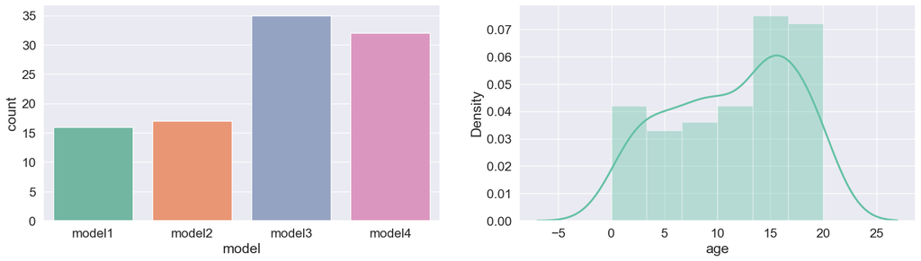

```python
# Visualize the distribution of machines by model and age using seaborn
fig, axes = plt.subplots(nrows=1, ncols=2, figsize=(20, 5))
fig.subplots_adjust(hspace=0.5)
sns.countplot(x="model", data=df_machines, ax=axes[0])
sns.distplot(df_machines["age"], ax=axes[1])
plt.show()
```

- More than 60 percent of the machines are of model 3 and 4.
- The age ranges from 0 to 20 years.

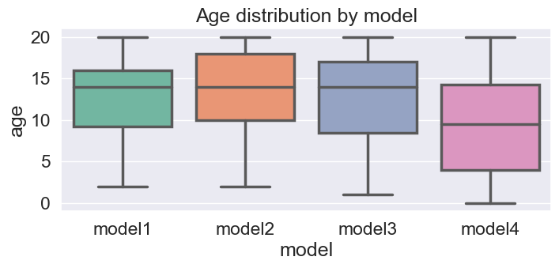

```python
# Age distribution in boxplot of each model
fig, ax = plt.subplots(figsize=(8, 3))
ax = sns.boxplot(x="model", y="age", data=df_machines)
ax.set_title("Age distribution by model")
plt.show()
```

```python
# value counts for each model
df_machines["model"].value_counts(normalize=True)
```

```
model
model3    0.35
model4    0.32
model2    0.17
model1    0.16
Name: proportion, dtype: float64
```

- The model4 machines are newer than the other models. The model2 machines are slightly older than the other models.

### Failure Data

These are the records of component replacements due to failures.

```python
df_failures["failure"] = df_failures["failure"].astype("category")
print(f"No. of failures: {df_failures.shape[0]}")
df_failures.head()
```

```
No. of failures: 761
```

|  | datetime | machineID | failure |
| --- | --- | --- | --- |
| 0 | 2015-01-05 06:00:00 | 1 | comp4 |
| 1 | 2015-03-06 06:00:00 | 1 | comp1 |
| 2 | 2015-04-20 06:00:00 | 1 | comp2 |
| 3 | 2015-06-19 06:00:00 | 1 | comp4 |
| 4 | 2015-09-02 06:00:00 | 1 | comp4 |

# Lets checks if there is the same failure for the same machine within 2 days

```python
def check_failure_within_2_days(df):
    # sort the data frame by machine ID and datetime
    df = df.sort_values(["machineID", "datetime"])

    # create a column for previous datetime
    df["previous_datetime"] = df.groupby(["machineID"])["datetime"].shift(1)

    # create a column for previous failure
    df["previous_failure"] = df.groupby(["machineID"])["failure"].shift(1)

    # create a column for days between failures
    df["days_between_failure"] = (df["datetime"] - df["previous_datetime"]).dt.days

    # create a column for failure within 7 days
    df["failure_within_2_days"] = (df["days_between_failure"] <= 2) & (
        df["failure"] == df["previous_failure"]
    )

    # drop the columns which are not needed
    df = df.drop(
        ["previous_datetime", "previous_failure", "days_between_failure"], axis=1
    )

    return df


df_failures = check_failure_within_2_days(df_failures)
# value counts for each failure_within_7_days
df_failures["failure_within_2_days"].value_counts(normalize=True)
```

```
failure_within_2_days
False    1.0
Name: proportion, dtype: float64
```

Nope. There are no repeated failures.

```python
# drop failure_within_2_days column
df_failures = df_failures.drop(["failure_within_2_days"], axis=1)
```

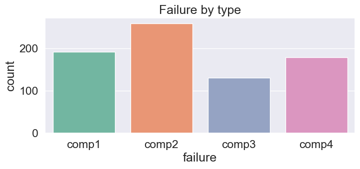

```python
# plot the failures by type with bar chart using seaborn
fig, ax = plt.subplots(figsize=(8, 3))
ax = sns.countplot(x="failure", data=df_failures)
ax.set_title("Failure by type")
plt.show()
```

```python
# value counts for each failure type normalized
df_failures["failure"].value_counts(normalize=True)
```

```
failure
comp2    0.340342
comp1    0.252300
comp4    0.235217
comp3    0.172142
Name: proportion, dtype: float64
```

- comp2 is the most common failure type

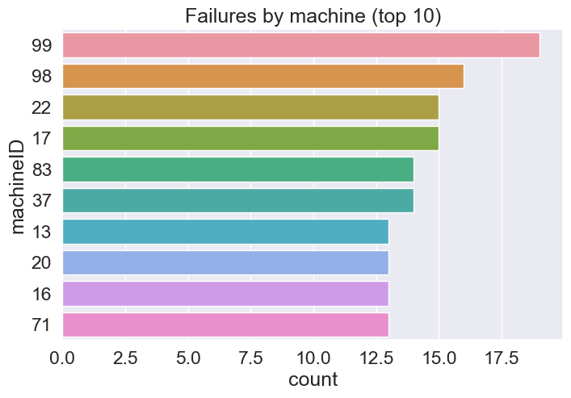

```python
# plot number of failures per machine. Only Top 10 shown.
fig, ax = plt.subplots(figsize=(8, 5))
ax = sns.countplot(
    y="machineID",
    data=df_failures,
    order=df_failures["machineID"].value_counts().iloc[:10].index,
)
ax.set_title("Failures by machine (top 10)")
plt.show()
```

```python
# Age of machine ID 99
df_machines.loc[df_machines["machineID"] == 99]
```

|  | machineID | model | age |
| --- | --- | --- | --- |
| 98 | 99 | model1 | 14 |

```python
# Which machinIDs has an age of 20?
df_machines.loc[df_machines["age"] == 20]
```

|  | machineID | model | age |
| --- | --- | --- | --- |
| 6 | 7 | model3 | 20 |
| 23 | 24 | model1 | 20 |
| 29 | 30 | model3 | 20 |
| 61 | 62 | model4 | 20 |
| 63 | 64 | model3 | 20 |
| 72 | 73 | model2 | 20 |
| 97 | 98 | model2 | 20 |

Does age the machine correlate with the number of failures?

```python
count_failure = df_failures.value_counts(["machineID"]).sort_index()
# convert the series to dataframe
count_failure = count_failure.to_frame().reset_index()

# sort the df_machines by machineID
df_machines = df_machines.sort_values(["machineID"])

# compute the correlation between age and number of failures
df_machines["age"].corr(count_failure["count"])
```

```
-0.11324822451125874
```

There seems to be no correlation.